# Differential expression analysis

Scott Campit

## Summary

This notebook performs differential expression analysis for various transcriptomics datasets.

## 1. Load libraries

First we’ll load some essential packages needed to run differential expression analysis.

```r
# Bioinformatics libraries
#install.packages("BiocManager")
#BiocManager::install(c("BiocManager", "edgeR",
#                   "DESeq2", "limma",
#                   "sva", "PCAtools",
#                   "Glimma", "bioMart"))

#install.packages("CePa", dependences=TRUE)
#BiocManager::install("Rgraphviz")
library(CePa)
library(edgeR)
library(DESeq2)
library(limma)
library(sva)
library(PCAtools)
library(Glimma)
library(biomaRt)

# Data science libraries
#install.packages(c("tidyverse", "readr", "rrcov"))
library(tidyverse)
library(readr)
library(rrcov)

remove(list=ls())
```

## 2. Perform data preprocessing

This code block performs essential data preprocessing for the cancer cell line encyclopedia data.

### Read in raw RNASeq counts

First, let’s load the table with the raw RNASeq gene counts.

```r
# ACLX path
#readpath = "C:\\Users\\scott\\Data\\RNASeq\\CCLE\\CCLE_934_TPM_EBI.tsv"
readpath = "C:\\Users\\scott\\Data\\RNASeq\\CCLE\\CCLE_RNAseq_genes_counts_20180929.gct"

# Dell
#readpath = "D:\\Data\\RNASeq\\CCLE\\CCLE_934_TPM_EBI.tsv"

# Load data either as a TPM or gene counts. I'm doing this from scratch.
#ccle = read_delim(file=readpath, delim='\t')

# Linux
#readpath = "~/Data/RNASeq/CCLE/CCLE_RNAseq_genes_counts_20180929.gct"
ccle = read.gct(readpath)
```

Note that in the raw gene count data matrix, the rows are labeled by Ensembl IDs, while the columns have the syntax CELLLINE_TISSUE, separated by an underscore. I can keep the Ensembl gene IDs, but I need to extract the tissue type, as this is a covariate of interest.

### Map genes to Entrez ID

First, since we’ll be using Entrez ID in the RECON1 model, we need to map ENSEMBL to Entrez.

```r
# Get map of Ensembl to Entrez
human = useMart("ensembl", dataset="hsapiens_gene_ensembl")
```

### Aggregate and remove duplicate cell line entries.

Note that some cell lines (columns) are duplicate entries. I need to aggregate them before moving on to additional preprocessing steps.

Now let’s begin preprocessing by grabbing some important meta data, specifically the tissue names.

```r
# Get data from the ccle dataframe
tmp = colnames(ccle)
tissue = word(string=tmp, start=2, end=-1, sep="_")
ccl = word(string=tmp, start=1, sep="_")

# Store into dataframe
colnames(ccle) = as.character(ccl)
```

Now we can being aggregating by cancer cell line.

```r
# Get entrez gene id
tmp = t(ccle)
entrezgene = tmp[1, ]
tmp = tmp[-1, ]

ccl = rownames(tmp)
rownames(tmp) = NULL

tissue = tissue[-1]
meta = data.frame("CCL"=ccl, "Tissue"=tissue)
meta = meta[!duplicated(ccl), ]

# Aggregate by cancer cell line
agg_tmp = aggregate(tmp, by=list(ccl), FUN=mean)
agg_tmp = t(agg_tmp)

agg_tmp = as.data.frame(agg_tmp)
colnames(agg_tmp) = agg_tmp[1, ]
agg_tmp = agg_tmp[-1, ]
rownames(agg_tmp) = ccle[, 1]
ccle = agg_tmp
rm(list = c("agg_tmp"))
```

### Missing value imputation

Note that there are missing values, so we’ll impute them with the minimum value in the dataset.

```r
min_impute = function(df){
  for (cols in colnames(df)) {
    if (cols %in% names(df[,sapply(df, is.numeric)])) {
      df = df %>% mutate(!!cols := replace(!!rlang::sym(cols),
                                           is.na(!!rlang::sym(cols)),
                                           min(!!rlang::sym(cols), na.rm=TRUE)))
    }
  }
  return(df)
}

tmp = DGEList(counts=data.matrix(ccle), genes=rownames(ccle))
keep = rowSums(cpm(tmp) >= 1) >= (ncol(tmp$counts)/5)
ccle = ccle[keep, ]
ccle = min_impute(ccle)
```

### Separate solid tumor and hematopoietic cancer cell lines

I need to separate the hematopoeitic and leukemia cell line lineages. Then I can perform differential expression analysis on both of the them separately.

```r
HL_idx = (meta[, 2] == "HAEMATOPOIETIC_AND_LYMPHOID_TISSUE")
HL_CCL = ccle[ , c(HL_idx)]
HL_tissue = meta[c(HL_idx), 2]
SOLID_CCL = ccle[ , !c(HL_idx)]
SOLID_tissue = meta[!c(HL_idx), 2]
```

### Remove outliers

We will first remove some outliers in both the HL and SOLID datasets using Robust PCA. It combines two ideas to find outliers: 1. Find projections with maximal dispersion using a grid search. 2. Estimate the covariance using an idea similar to Hubert robust regression.

First, we’ll define a function to do this filtering.

```r
# Create a function that filters data using ROBPCA
removeOutliers = function(data, id){
  pca_obj = PcaHubert(data)
  filtered_data = data[pca_obj@flag, ]
  filtered_id = id[pca_obj@flag]
  outlier_data = data[!pca_obj@flag, ]
  outlier_id = id[!pca_obj@flag]

  setClass(Class="geneObj",
           representation(
             data="matrix",
             outlier_data="matrix",
             id="character",
             flag="logical",
             outlier_id="character"
           )
   )
   return(new("geneObj",
          data=filtered_data,
          outlier_data=outlier_data,
          id=filtered_id,
          flag=pca_obj@flag,
          outlier_id=outlier_id))
}
```

Now let’s do this filtering for both genes and cell lines.

```r
# Construct the input for PcaHubert of class matrix
HL_data = data.matrix(HL_CCL)
SOLID_data = data.matrix(SOLID_CCL)

# Use removeOutliers to remove noisy genes
HL_geneFilter = removeOutliers(HL_data, rownames(HL_data))
SOLID_geneFilter = removeOutliers(SOLID_data, rownames(SOLID_data))
```

```r
# Now set the stage to remove noisy cancer cell lines
HL_data2 = data.matrix(HL_geneFilter@data)
SOLID_data2 = data.matrix(SOLID_geneFilter@data)

HL_data2 = t(HL_data2)
SOLID_data2 = t(SOLID_data2)

HL_allFilter = removeOutliers(HL_data2, meta[, 1])
SOLID_allFilter = removeOutliers(SOLID_data2,  meta[, 1])
```

The final dataframe will be constructed here.

```r
# Construct the final dataframe
HL_final = t(data.matrix(HL_allFilter@data))
SOLID_final = t(data.matrix(SOLID_allFilter@data))
rownames(HL_final) = c(HL_geneFilter@id)
rownames(SOLID_final) = c(SOLID_geneFilter@id)
final_tissue = meta[SOLID_allFilter@flag, 2]
```

If we want to do a final sanity check, here’s a code block that can make those plots.

[figure not shown]

```r
tmp = t(data.matrix(SOLID_final))
colnames(tmp) = NULL
rownames(tmp) = NULL

# Visualize cancer cell lines in 2D space
solid_pc_filtered = PCAtools::pca(tmp)
PCAtools::screeplot(solid_pc_filtered)
```

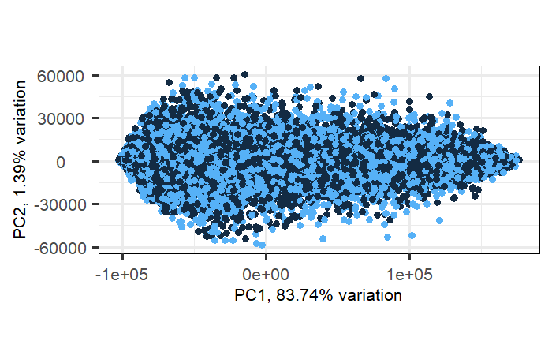

```r
PCAtools::biplot(solid_pc_filtered,
                 x="PC1", y="PC2")
```

[figure not shown]

```r
PCAtools::pairsplot(solid_pc_filtered)
```

[figure not shown]

```r
# Visualize genes in 2D space
tmp = data.matrix(SOLID_final)
colnames(tmp) = NULL
rownames(tmp) = NULL

solid_pc_filtered = PCAtools::pca(tmp)
PCAtools::screeplot(solid_pc_filtered)
```

```r
PCAtools::biplot(solid_pc_filtered)
```

[output not shown]